# Dating survey analysis

Rohan Selva-Radov

2024-06-07

Data are from the [2023 American Perspectives Survey](https://www.americansurveycenter.org/download/january-2023-american-perspectives-survey/). Full GitHub repository is [here](https://github.com/rohanselvaradov/APS_jan23).

**For all of the following, we pre-filter to only consider respondents in the 18-29 age group.**

I present all the graphs first stacked by gender to allow comparisons more easily, and then the identical analyses side-by-side to visualise distributions better.

## Stacked bar plots

I think the first question is strangely worded – if I were dating someone but it’s not a “committed” relationship, I probably wouldn’t say that I was “Single or not currently in a relationship”, but I wouldn’t fit into the “In a committed relationship, but not living together” category either.

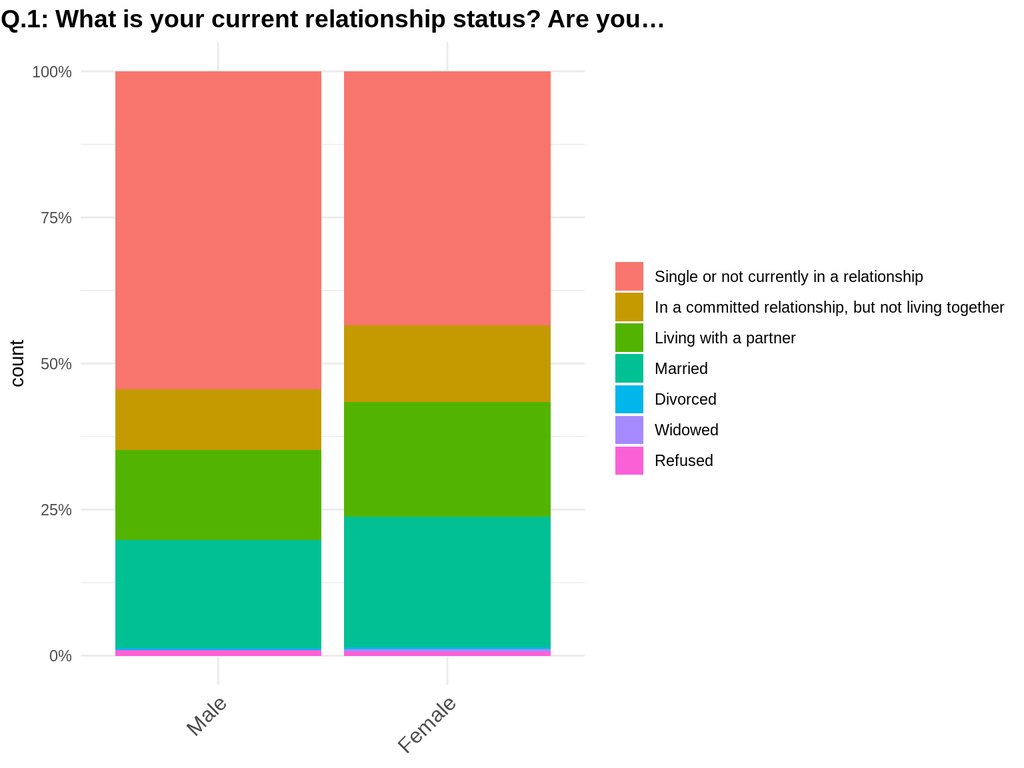

```r
plot_question_by_gender_stacked(df, "Q1")
```

The next question is only asked to respondents who said they were single or not in a relationship.

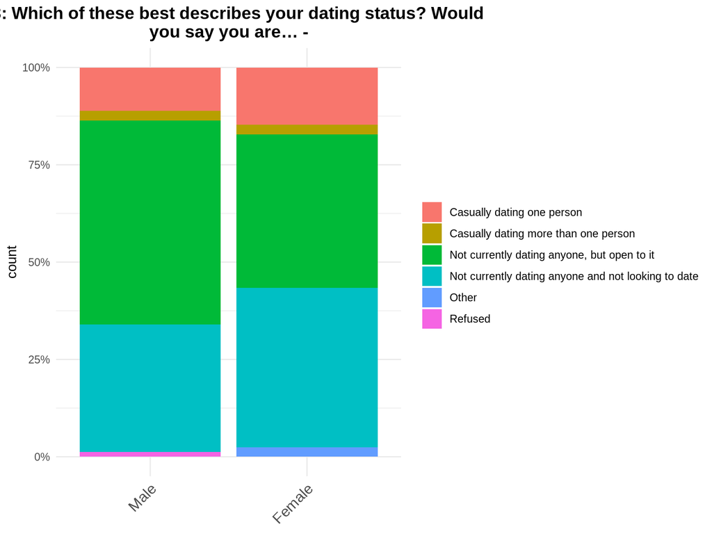

```r
plot_question_by_gender_stacked(df, "Q3")
```

The next question is only asked to respondents who said they were single or not in a relationship, and additionally are not casually dating anybody.

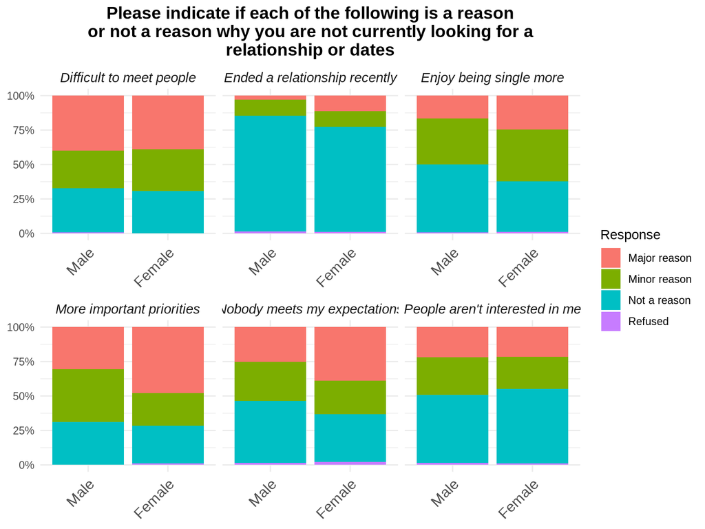

```r
plot_question_set_by_gender_stacked(df, "Q4", "Please indicate if each of the following is a reason or not a reason why you are not currently looking for a relationship or dates")
```

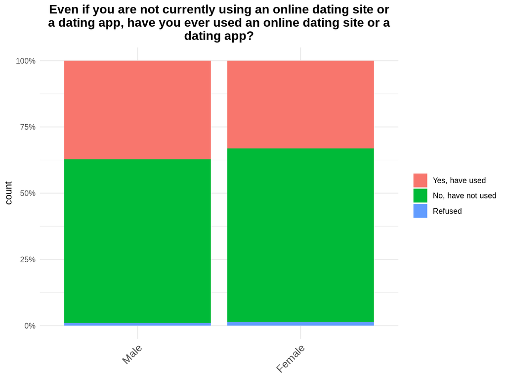

```r
plot_question_by_gender_stacked(df, "Q13", "Even if you are not currently using an online dating site or a dating app, have you ever used an online dating site or a dating app?")
```

The next two questions are only asked to respondents who said they had at some point used an online dating site or app.

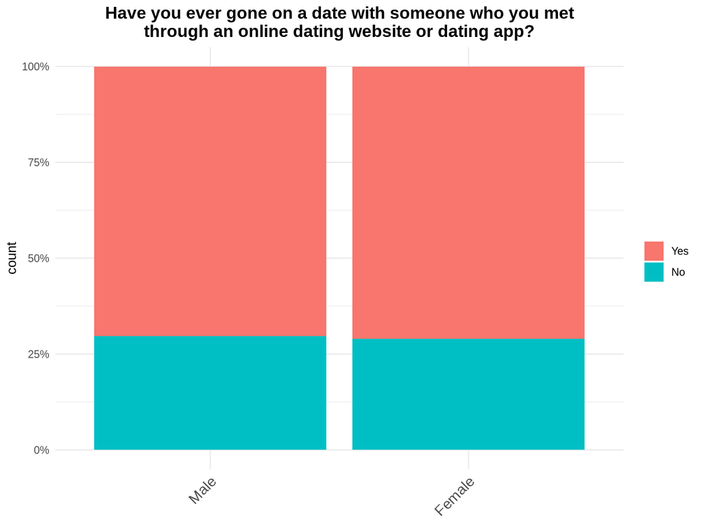

```r
plot_question_by_gender_stacked(df, "Q14", "Have you ever gone on a date with someone who you met through an online dating website or  dating app?")
```

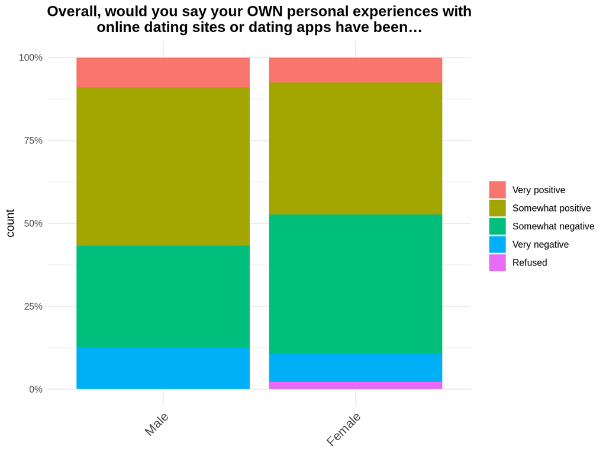

```r
plot_question_by_gender_stacked(df, "Q15", "Overall, would you say your OWN personal experiences with online dating sites or dating apps have been…")
```

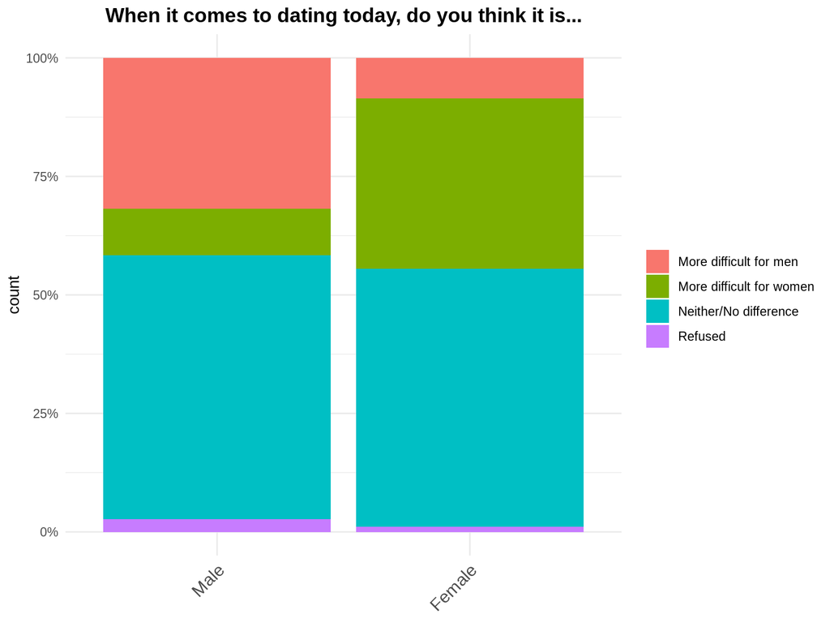

```r
plot_question_by_gender_stacked(df, "Q17", "When it comes to dating today, do you think it is...")
```

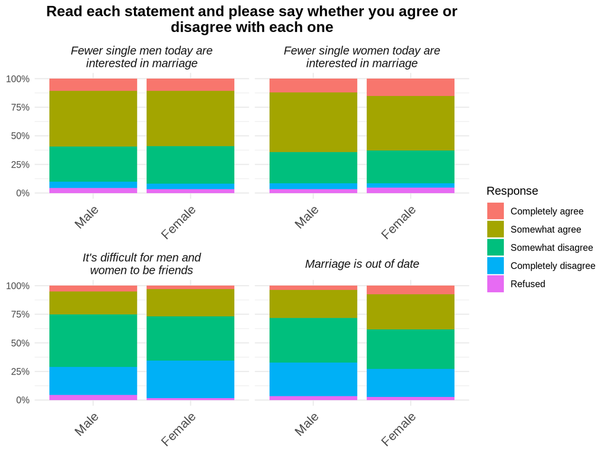

```r
plot_question_set_by_gender_stacked(df, "Q21", "Read each statement and please say whether you agree or disagree with each one")
```

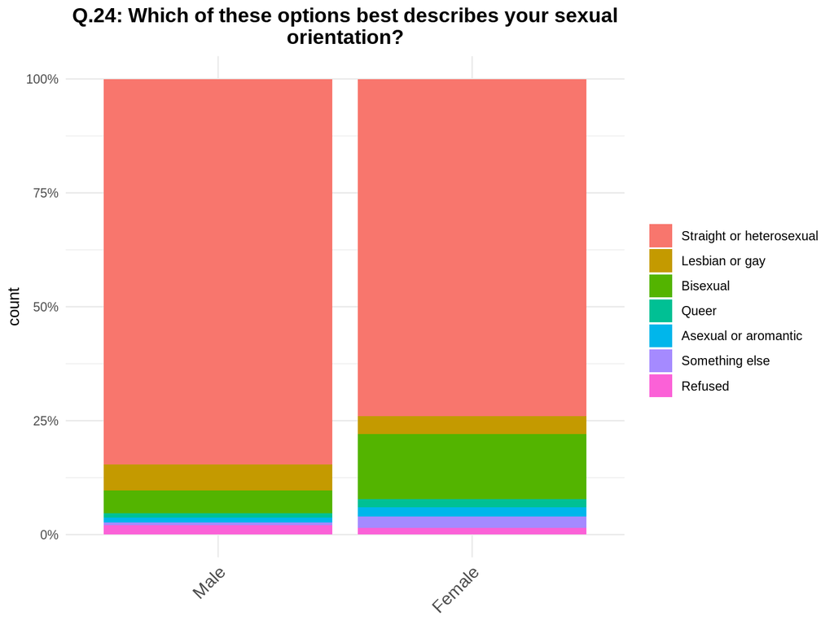

```r
plot_question_by_gender_stacked(df, "Q24")
```

The next question is only asked to respondents who said they were not straight/heterosexual.

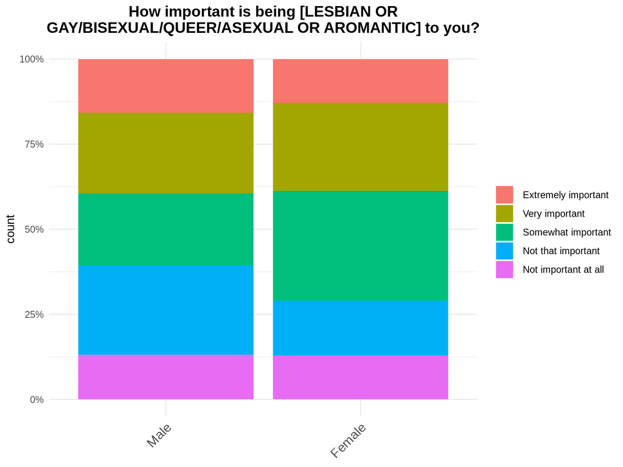

```r
plot_question_by_gender_stacked(df, "Q25", "How important is being [LESBIAN OR GAY/BISEXUAL/QUEER/ASEXUAL OR AROMANTIC] to you?")
```

## Side-by-side bar plots

I think the first question is strangely worded – if I were dating someone but it’s not a “committed” relationship, I probably wouldn’t say that I was “Single or not currently in a relationship”, but I wouldn’t fit into the “In a committed relationship, but not living together” category either.

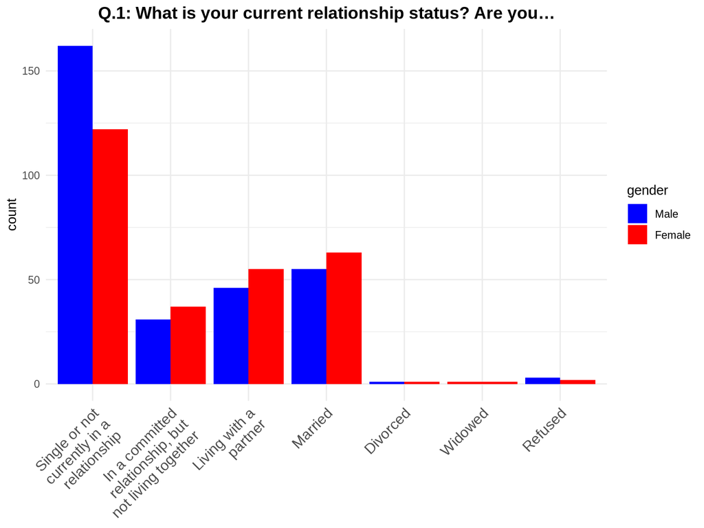

```r
plot_question_by_gender(df, "Q1")
```

The next question is only asked to respondents who said they were single or not in a relationship.

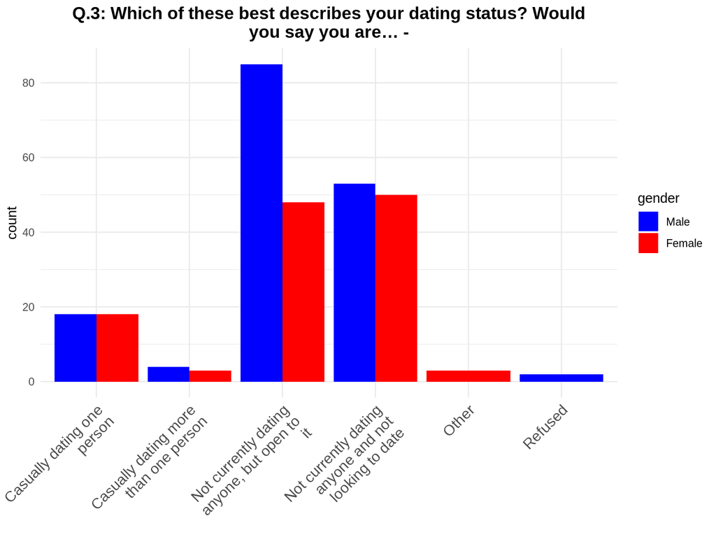

```r
plot_question_by_gender(df, "Q3")
```

The next question is only asked to respondents who said they were single or not in a relationship, and additionally are not casually dating anybody.

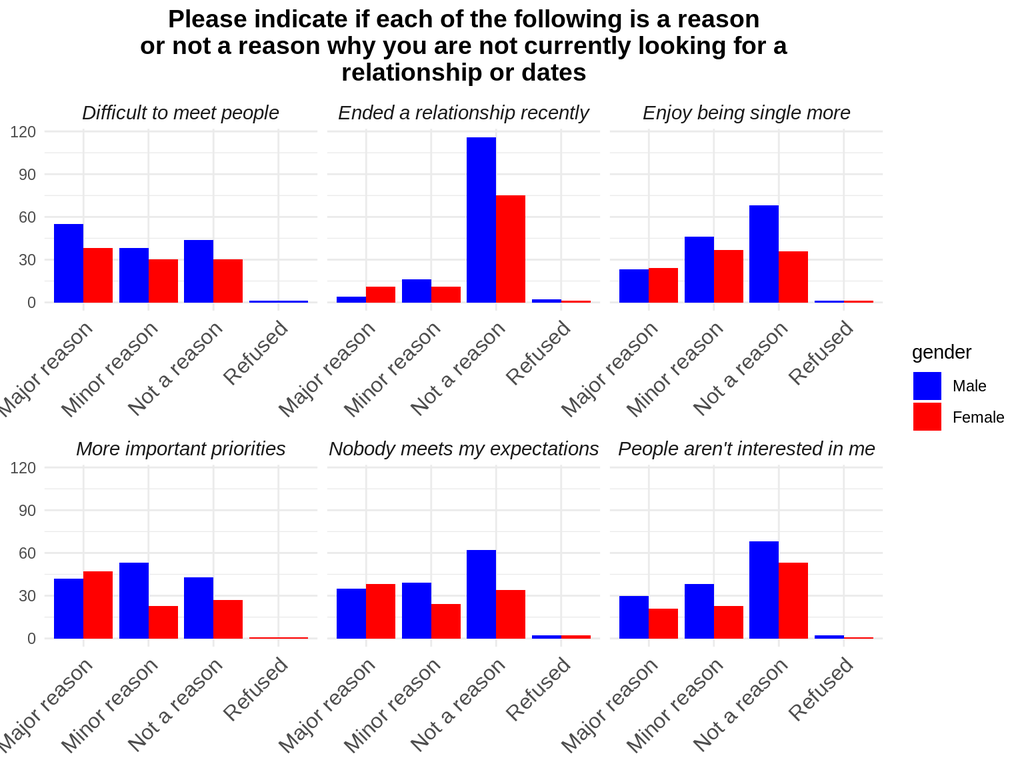

```r
plot_question_set_by_gender(df, "Q4", "Please indicate if each of the following is a reason or not a reason why you are not currently looking for a relationship or dates")
```

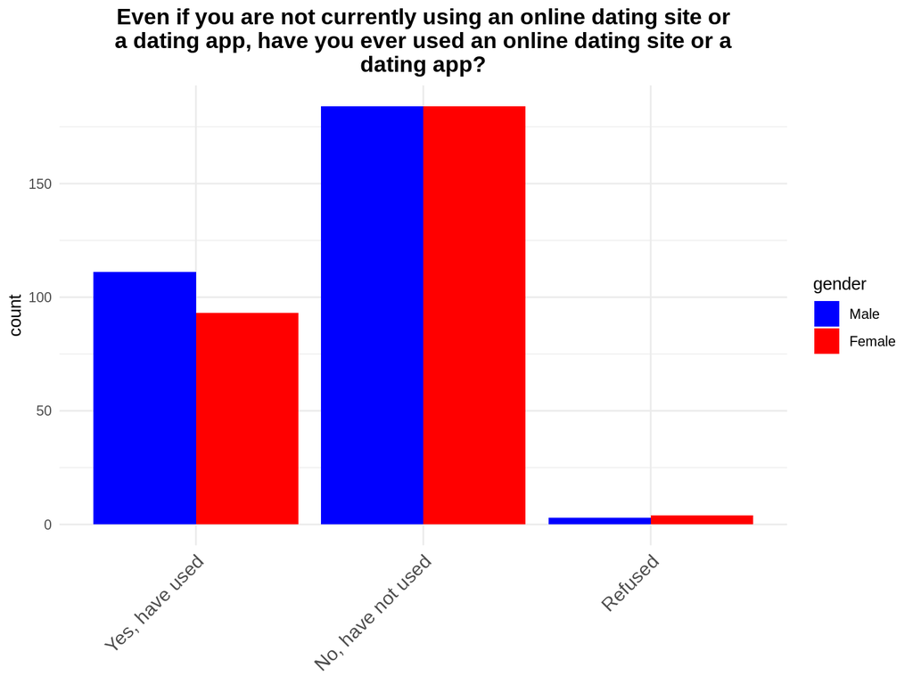

```r
plot_question_by_gender(df, "Q13", "Even if you are not currently using an online dating site or a dating app, have you ever used an online dating site or a dating app?")
```

The next two questions are only asked to respondents who said they had at some point used an online dating site or app.

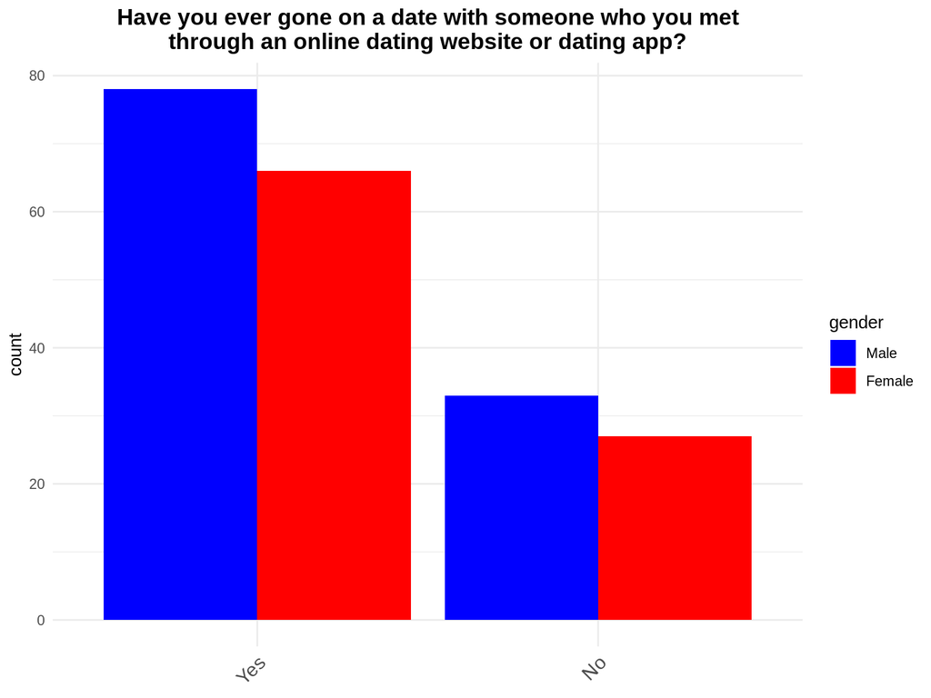

```r
plot_question_by_gender(df, "Q14", "Have you ever gone on a date with someone who you met through an online dating website or  dating app?")
```

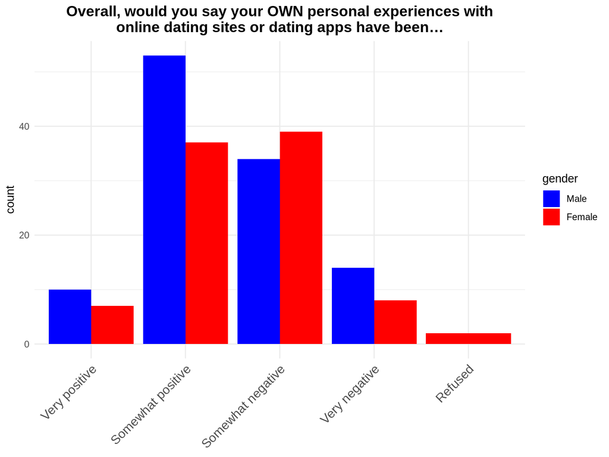

```r
plot_question_by_gender(df, "Q15", "Overall, would you say your OWN personal experiences with online dating sites or dating apps have been…")
```

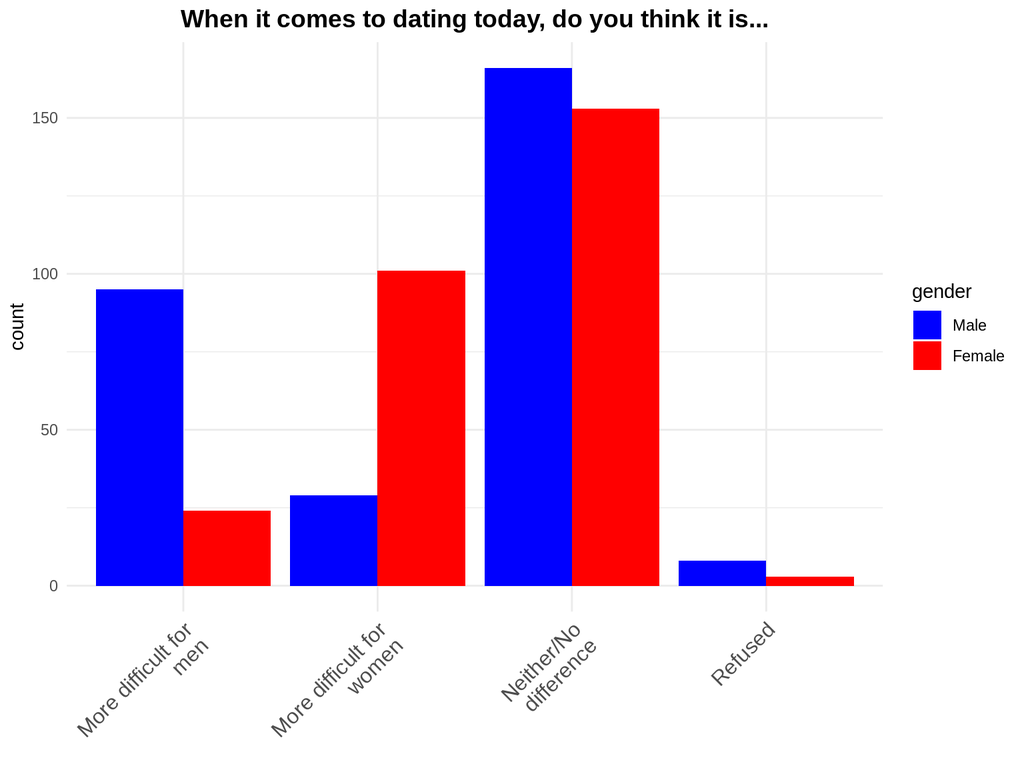

```r
plot_question_by_gender(df, "Q17", "When it comes to dating today, do you think it is...")
```

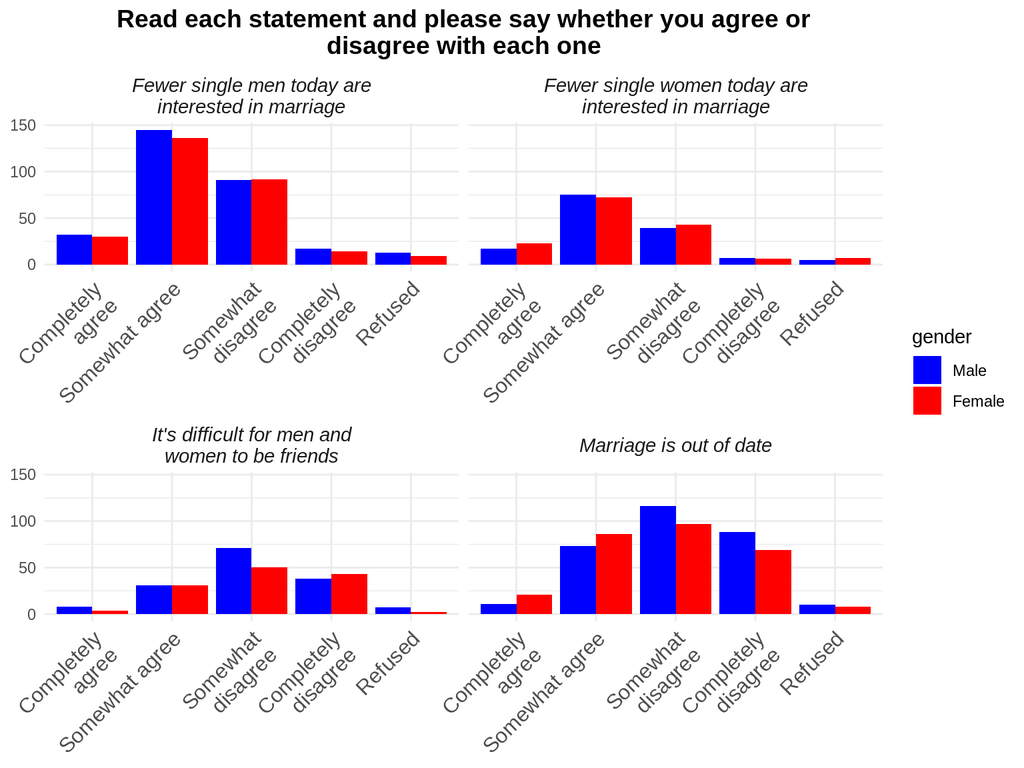

```r
plot_question_set_by_gender(df, "Q21", "Read each statement and please say whether you agree or disagree with each one")
```

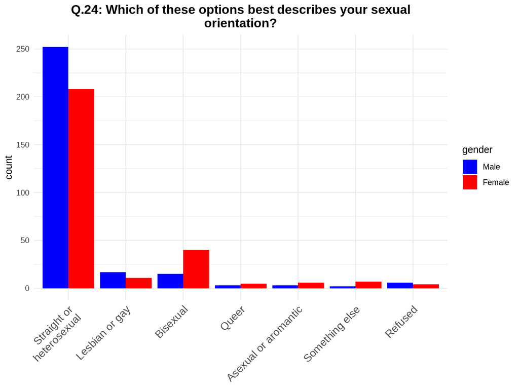

```r
plot_question_by_gender(df, "Q24")
```

The next question is only asked to respondents who said they were not straight/heterosexual.

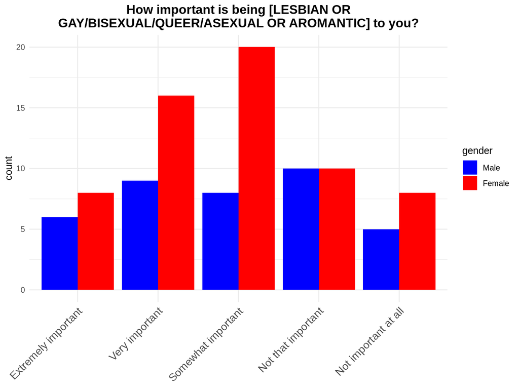

```r
plot_question_by_gender(df, "Q25", "How important is being [LESBIAN OR GAY/BISEXUAL/QUEER/ASEXUAL OR AROMANTIC] to you?")
```